# Relatório Final

Gabriella Cukier

### Bibliotecas

```python
import subprocess
import time
import pandas as pd
import matplotlib.pyplot as plt
import pickle
import numpy as np
import matplotlib.pyplot as plt
```

```python
from mpl_toolkits.mplot3d import Axes3D
import matplotlib.pyplot as plt
from matplotlib import cm
from matplotlib.ticker import LinearLocator, FormatStrFormatter
```

```python
def multi_df(dic):
    # https://www.geeksforgeeks.org/nested-dictionary-to-multiindex-dataframe/
    reformed_dict = {}
    for outerKey, innerDict in dic.items():
        for innerKey, values in innerDict.items():
            reformed_dict[(outerKey,
                           innerKey)] = values

    multiIndex_df = pd.DataFrame(reformed_dict)
    return multiIndex_df
```

```python
def exe_dict(executaveis):
    dic = {}
    for x in executaveis:
        a_file = open(f"cache/{x}.pkl", "rb")
        output = pickle.load(a_file)
        a_file.close()
        dic_new = output
        dic.update(dic_new)
    return dic
```

```python
def create_df(executaveis, initial, val_range, step):
    dic = exe_dict(executaveis)
    df = pd.DataFrame(dic)
    multiIndex_df = pd.DataFrame(multi_df(dic))

    valores=[initial]
    for i in range (1,val_range):
        valores.append(valores[i-1]+step)
    multiIndex_df["tamanho-entrada"] = valores
    multiIndex_df = multiIndex_df.set_index("tamanho-entrada")
    return valores, df, multiIndex_df
```

```python
def df_from_dic(dic):
    df = pd.DataFrame(dic)
    multiIndex_df = pd.DataFrame(multi_df(dic))

    valores=[initial]
    for i in range (1,val_range):
        valores.append(valores[i-1]+step)
    multiIndex_df["tamanho-entrada"] = valores
    multiIndex_df = multiIndex_df.set_index("tamanho-entrada")
    return valores, df, multiIndex_df
```

```python
def exhaustive_regression(start, end, degree, dic, valores):

    x = np.array(valores).astype(np.float)
    y = np.array(list(dic[('busca_exaustiva_smith_waterman', 'times')].values())).astype(np.float)
    y_exe = np.array(list(dic[('exaustiva-paralela-reduce', 'times')].values())).astype(np.float)

    model = np.poly1d(np.polyfit(x, y, degree))
    x_future_sw = np.linspace(start, end, int((end-start)))
    y_future_sw = model(x_future_sw)

    model = np.poly1d(np.polyfit(x, y_exe, degree))
    x_future_exe = np.linspace(start, end, int((end-start)))
    y_future_exe = model(x_future_exe)


    regression_sw = {
        "size" : x_future_sw,
        "times_sw" : y_future_sw,
        "times_exe" : y_future_exe
    }

    df_regression_sw = pd.DataFrame(regression_sw)
    df_regression_sw

    return df_regression_sw
```

## Descrição e Objetivos

O presente projeto trabalha o problema da área de Bioinformática conhecido como alinhamento de sequências de DNA, que consiste em uma comparação entre sequências de bases nitrogenadas, de forma a encontrar seu nível de similaridade.

Tal nível de similaridade pode ser convertido em um score numérico, com base em certos pesos atribuídos aos acertos (match) e erros (gap e mismatch). Nas implementações apresentadas a seguir, os pesos foram definidos da seguinte forma:

- Match = 2
- Mismatch = -1
- Gap = -1

O objetivo é encontrar as sequências que tenham o maior nível de similaridade, ou seja, o maior score entre elas.

Diversas estratégias foram implementadas visando a alcançar este objetivo, sendo elas:

- Solução Heurística (método de Smith Waterman)
- Busca Local com aleatoriedade
- Busca Exaustiva

Em seguida, foram implementados métodos de otimização de velocidade para esta última implementação exaustiva, sendo eles:

- Paralelização por OpenMP
- Utilização de GPU

A seguir, cada uma destas implementações será descrita detalhadamente e seus resultados comparados e discutidos.

## Testes

Todas as implementações possuiam duas sequências de DNA como entradas. A saída esperada era um score máximo de alinhamento, com as sequências correspondentes encontradas.

Para cada um dos programas descritos a seguir, as entradas para teste foram geradas por um código fornecido no enunciado, mostrado abaixo:

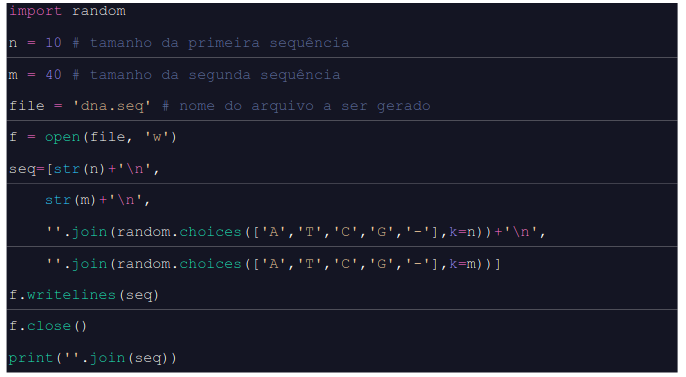

O output deste código foi salvo num arquivo chamado dna.seq, que contém o seguinte formato:

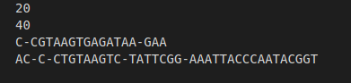

As duas primeiras linhas indicam o tamanho das sequências de entrada A e B, respectivamente. As linhas seguintes contêm as sequências correspondentes geradas.

Vários testes foram gerados em todas as etapas do projeto. Além disso, especificamente para a etapa de Smith Waterman, os resultados foram comparados aos de referência do site: https://rna.informatik.uni-freiburg.de/Teaching/index.jsp?toolName=Smith-Waterman

#### Salvando arquivos

Para otimizar o processo de análise, os resultados das execuções dos códigos foram salvos em arquivos do tipo pickle.

## Para rodar

Para rodar os programas, é necessário seguir os seguintes passos (dentro da pasta codigos):

1. Compilar a. Smith waterman | Busca local | Busca exaustiva

   ```
     g++ -Wall -O3 programa.cpp -o programa
   ```

   b. Paralelismo com OpenMP

   ```
     g++ -Wall -O3 -fopenmp -g programa.cpp -o programa
   ```

   b. GPU

   ```
     nvcc -arch=sm_70 -std=c++14 programa.cu -o programa
   ```

2. Rodar, indicando entradas e saídas

   ```
     ./programa < ../inputs/dna.seq > ../outputs/programa
   ```

## Smith Waterman

A etapa inicial do projeto implementa a Heurística de Alinhamento Local de Smith- Waterman, aplicada a duas sequências de DNA fornecidas como input, calculando o score máximo de alinhamento entre elas. Em seguida, reconstrói o alinhamento local ótimo das duas sequências.

### Funcionamento

A Heurística de Alinhamento Local de Smith-Waterman consiste em um algoritmo que segue os seguintes passos:

1. Inicializa uma matriz n x m com as linhas e colunas na posição 0 (em ambos os eixos) contendo o valor 0
2. Para cada 1≤i≤n e 1≤j≤m:
3. Calcula a diagonal de acordo com a seguinte fórmula: H[i-1,j-1] + w(a[i],b[j]) onde:
   - w(a[i],b[j])=2 se houve match,
   - w(a[i],b[j])= -1 se houve mismatch e
   - w(a[i],b[j])= -1 se houve gap
1. Calcula a deleção por meio de H[i-1,j] - 1
2. Calcular a inserção por meio de H[i,j-1] - 1
3. Atribui à posição da matriz H[i,j] o máximo dentre os valores;
   - diagonal
   - deleção
   - inserção
   - 0 (de forma a nunca ser negativo)
4. Por fim, retorna o valor máximo da matriz

Durante a construção da matriz, o caminho seguido foi armazenado em um struct, de forma que, partindo da posição do score máximo encontrado, foi possível retornar no caminho, o que permitiu reconstruir as sequências com o melhor alinhamento possível. Este caminho foi determinado com a seguinte correspondência:

- deleção = salto de cima para baixo
- inserção = salto da esquerda para a direita
- diagonal

Desta forma, foi armazenada no struct a movimentação necessária nos eixos X e Y, de acordo com a descrição acima, além do valor calculado para cada posição.

Um exemplo de como essa reconstrução ocorre, calculado por meio de uma ferramenta de verificação do cálculo de Smith Waterman, é apresentado a seguir:

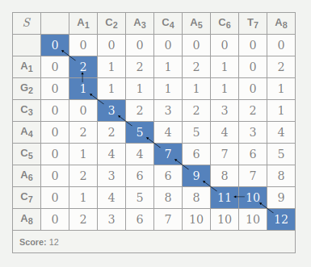

## Busca local

Esta etapa inicial do projeto implementa a estratégia de Busca Local com Aleatoriedade, aplicada a duas sequências de DNA fornecidas como input, calculando o score máximo de alinhamento entre elas, por meio da divisão em subsequências. Tal estratégia de divisão em problemas menores tem o intuito de diminuir o tempo de processamento, principalmente para sequências muito grandes

### Funcionamento

O algoritmo funciona por meio dos seguintes passos:

1. Lê duas sequências de DNA com tamanho especificado (a - tamanho n e b - tamanho m), contidas em um arquivo de entrada
2. Para gerar a subsequência, devemos fornecer um ponto de início da sequência original (j) e o tamanho que esta subsequência terá (k). Estes valores foram gerados aleatoriamente, no intervalo:

   ```
                k, 1<=k<=m
   ```

   e

   ```
                 j, 0<=j<=m-k
   ```

   Por exemplo, se o tamanho sorteado da sequência de entrada AGCACACA for 3 e j=1, teríamos a seguinte subsequência:

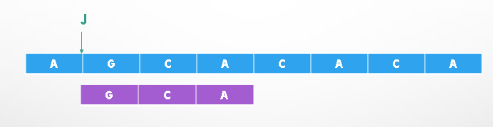

1. Gerou-se um número positivo p, correspondente ao número de subsequências da entrada a que serão geradas para serem comparadas com sb. Neste projeto, foi determinado que o valor de p deve ser o dobro de k, um valor suficientemente grande para que se obtenha diversidade nas sequências aleatórias geradas (principalmente para entradas maiores). É esperado que quanto maior o valor de p, maior a chance de se encontrar um score melhor, porém maior o tempo de execução. De acordo com a necessidade, os limiares de p podem ser ajustados.
2. Foi sorteado um número i, 0<=i<=n (correspondente ao ponto de início na sequência a) e p sequências sa com o tamanho k calculado previamente foram geradas. Estas sequências foram armazenadas em um vetor para futura comparação de alinhamento.
3. Percorrendo o vetor das subsequências sa armazenadas, foram comparadas as bases nitrogenadas em cada posição com a posição correspondente da subsequência sb. Os scores de cada par (sa,sb) foram calculados com os pesos wmat=2, wmis=-1 e wgap=-1
4. O score máximo do cálculo do passo anterior e as subsequências correspondentes a ele foram armazenados e retornados pela função
5. Para melhorar o valor máximo de score encontrado, o algoritmo foi rodado múltiplas vezes (1000). Tal valor escolhido arbitrariamente segue a mesma lógica de p, ou seja, quanto maior, maior a chance de se encontrar um score melhor, porém maior o tempo de execução.

## Busca Exaustiva

### Metodologia

Na Busca Exaustiva, uma solução ótima de um problema é encontrada, por meio da geração de todas as soluções possíveis.

Sendo uma entrada composta por duas sequências de DNA (A e B), o código implementado funciona por meio das seguintes etapas:

1. Geração de todas as subsequências de A e de B
2. Cálculo dos alinhamentos de cada par de subsequencias de A e de B (com os pesos wmat, wmis e wgap). Foram utilizadas as seguintes estratégias para o cálculo:

   2.1. Alinhamento pelo método de Smith Waterman

   2.2. Score simples, por meio de uma comparação direta entre as duas subsequências, sendo a maior truncada para que ambas possuam o mesmo tamanho

   2.3. Uma mistura das duas estratégias descritas acima, sendo o score simples utilizado no cálculo de quando as sequências possuem o mesmo tamanho e o método de Smith Waterman, caso contrário.
1. A saída do programa será composta do score de alinhamento, além das subsequências correspondentes alinhadas.

## Busca Exaustiva multicore - OpenMP

Para a implementação da estratégia de paralelização foi escolhido o projeto de busca exaustiva. Este foi um dos que obteve um desempenho mais lento. Além disso, é bastante paralelizável, já que existem muitas subsequências cujo score deve ser calculado, o que é feito sem a existência de dependências entre elas. Ou seja, o loop de cálculo de scores era ingenuamente paralelizável.

Desta forma, identifica-se uma situação em que a mesma operação de cálculo de scores (lenta) é executada para todos os elementos de um conjunto de dados (grande), o que é uma situação ideal par a a implementação de um paralelismo de dados.

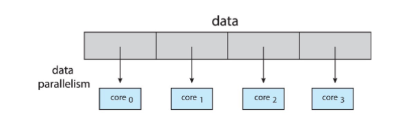

Portanto, o uso de threads para calcular scores para diferentes sequências se apresenta como uma boa opção.

A estratégia escolhida foi a implementação de um parallel for. Para isso, as subsequências geradas foram armazenadas em um único vetor

Em uma primeira implementação, este grande vetor continha um índice incremental e as duas subsequências correspondentes, pertencentes a cada uma das entradas.

Em seguida, este vetor era percorrido dentro de um Parallel for. Em um novo vetor, os valores dos resultados eram armazenados no índice correspondente, de modo a não ocorrerem conflitos entre as threads. Por fim, este vetor preenchido era percorrido e o melhor resultado era salvo, juntamente com as subsequências correspondentes.

Visando a otimizar esta implementação, foi implementada a estratégia de utilizar o parallel for com reduction, de forma que o melhor resultado entre as threads (valor máximo de score encontrado) fosse devolvido.

No entanto, ainda existia um problema. O vetor gerado que continha todas as subsequências ficava muito grande, o que causava um estouro na memória.

Para contornar isso, a estratégia utilizada foi calcular o score de forma paralelizada por blocos. Ou seja, foi determinado um tamanho máximo que o vetor de subsequências poderia alcançar. Quando este valor era atingido, os scores eram calculados, divididos em threads. Em seguida, o vetor com as combinações era esvaziado e o processo continuava, partindo para o próximo bloco, até que o tamanho do vetor das subsequências acabasse.

## Busca exaustiva manycore - GPU

Nesta etapa, foi utilizada uma estratégia conjunta, que combinava a implementação com OpenMP, acrescentando a utilzação da GPU.

Desta forma, manteve-se a etapa de gerar um grande vetor com todos os pares de subsequências possíveis e calcular o score de forma paralelizada, por meio do OpenMP. Porém, agora o cálculo do score ocorre dentro da GPU.

Vale ressaltar, contudo, que em termos de velocidade a CPU é superior. O que diferencia a GPU é sua capacidade de alta vazão de dados (throughput), otimizados para o processamento de forma paralela.

Além disso, no caso desta implementação, o endereçamento de memória é separado, de forma que os dados precisam ser copiados para a GPU, o que leva tempo.

Desta maneira, para tornar a implementação mais rápida, é necessário enviar vários dados por vez para serem processados simultaneamente na GPU. Isso foi feito usando a estratégia de enviar as subsequências cujo score deveria ser calculado em lotes de tamanho definido e depois retornar apenas o melhor resultado de todo o lote.

Assim, dentro dos threads lançados pelo parallel for, o vetor foi cortado, de modo que cada thread lançasse os lotes para a GPU. Após calculado o score, a função responsável pelo cálculo na GPU retornava apenas o melhor dentre todos os scores encontrados. Por fim, o reduction implementado nas threads identificava apenas o valor máximo.

Depois que as threads acabavam seu processamento, este valor máximo era comparado com um valor máximo global, de forma a salvar apenas o melhor resultado.

Em seguida, o vetor com as combinações de subsequências era esvaziado e o processo se repetia até que todas as subsequências tenham sido processadas.

No entanto, percebe-se que existem combinações de subsequências cujo valor atingido nunca poderá ser o máximo, como por exemplo, aquelas de tamanho muito pequeno. Levando isso em consideração, foi implementada também uma estratégia de Branch & Bound para vetores de entrada maiores, de forma que, após o primeiro bloco de scores ser processado e um primeiro máximo obtido, este valor era comparado com o máximo possível de cada sequência. Se não fosse identificada a possibilidade de melhoria, tais subsequências não eram incluídas no cálculo.

# Resultados

## Smith Waterman e Busca Local

Os resultados e os tempos de execução de cada programa foram salvos em em arquivos do tipo pickle e carregados em dataframes e seus resultados analisados

```python
executaveis =["smith_waterman","busca-local"]
```

```python
valores, df_p1_p2, multiIndex_df_p1_p2 = create_df(executaveis, 10, 17, 50)
multiIndex_df_p1_p2
```

| tamanho-entrada | smith_waterman results | smith_waterman times | busca-local results | busca-local times |
| --- | --- | --- | --- | --- |
| 10 | 7 | 0.008798 | 5 | 0.008217 |
| 60 | 37 | 0.005554 | 17 | 0.064753 |
| 110 | 52 | 0.005117 | 10 | 0.200295 |
| 160 | 94 | 0.005273 | 16 | 0.497627 |
| 210 | 118 | 0.005820 | 15 | 0.817216 |
| 260 | 153 | 0.009513 | 14 | 1.155799 |
| 310 | 184 | 0.007044 | 13 | 1.758841 |
| 360 | 197 | 0.007508 | 13 | 2.519806 |
| 410 | 235 | 0.008086 | 12 | 3.117221 |
| 460 | 282 | 0.009274 | 14 | 4.023556 |
| 510 | 313 | 0.010432 | 13 | 5.047465 |
| 560 | 316 | 0.010860 | 12 | 5.842523 |
| 610 | 333 | 0.012595 | 20 | 7.423180 |
| 660 | 396 | 0.013286 | 13 | 8.070794 |
| 710 | 407 | 0.015220 | 19 | 9.607409 |
| 760 | 439 | 0.015914 | 17 | 10.877430 |
| 810 | 488 | 0.017736 | 14 | 11.978906 |

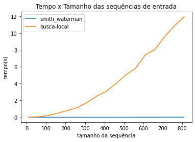

```python
for exe in df_p1_p2.columns.values.tolist():
    plt.plot(valores,multiIndex_df_p1_p2[exe]["times"].values.astype(float), label=exe)
plt.legend()
plt.title("Tempo x Tamanho das sequências de entrada")
plt.xlabel("tamanho da sequência")
plt.ylabel("tempo(s)")
```

##### Ampliação do gráfico de Smith Waterman

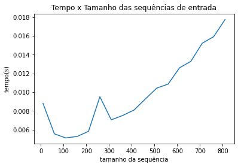

```python
plt.plot(valores,multiIndex_df_p1_p2["smith_waterman"]["times"].values.astype(float))
plt.title("Tempo x Tamanho das sequências de entrada")
plt.xlabel("tamanho da sequência")
plt.ylabel("tempo(s)")
```

#### Gráfico dos resultados em função do tamanho da sequência

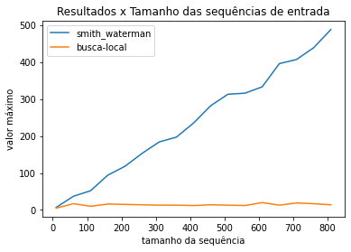

```python
for exe in df_p1_p2.columns.values.tolist():
    plt.plot(valores,multiIndex_df_p1_p2[exe]["results"].values.astype(float), label=exe)
plt.legend()
plt.title("Resultados x Tamanho das sequências de entrada")
plt.xlabel("tamanho da sequência")
plt.ylabel("valor máximo")
```

##### Ampliação do gráfico da busca local

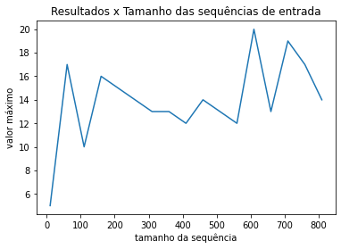

```python
plt.plot(valores,multiIndex_df_p1_p2["busca-local"]["results"].values.astype(float))
plt.title("Resultados x Tamanho das sequências de entrada")
plt.xlabel("tamanho da sequência")
plt.ylabel("valor máximo")
```

Tanto no gráfico do tempo, quanto no dos resultados, ambos em em função do tamanho da sequência, o algoritmo de Smith Waterman aparentou obter um desempenho melhor, com resultados mais desejados em relação ao tempo e aos valores.

Uma possível explicação é que como o algoritmo de busca local roda o programa inúmeras vezes, de forma a atingir um maior nível de aleatoriedade e testar mais sequências, ele tende a demorar mais.

Ademais, os testes mostraram que no programa de busca local, um alto valor de p favoreceu um desempenho melhor dos resultados, já que permitiu que múltiplas sequências fossem testadas, procurando assim as que melhor se alinhavam. Contudo, o valor de k, correspondente ao tamanho das subsequências, por ser pequeno, ainda foi um limitante para o score máximo.

Outro fator limitante desta implementação foi que, como ela não considera os gaps de alinhamento, como a de Smith Waterman, o score final tende a ser menor.

## Resultados: Busca Exaustiva

#### Metodologia da comparação

Como a estratégia da busca exaustiva consiste em testar todas as possibilidades possíveis e assim achar uma solução ótima global, ela tende a ser mais computacionalmente custosa. Desta forma, para fins de teste de desempenho, foi utilizado um intervalo com valores mais baixos referentes ao tamanho da sequência.

Mais adiante, estes valores foram utilizados como base na criação de um modelo de regressão, que, após validado, permitiu a comparação entre algoritmos com limites superiores maiores.

Os respectivos resultados de cada programa foram salvos em um dataframe, assim como os tempos de execução correspondentes. Por fim, foram elaborados gráficos comparativos e seus resultados analisados

##### Criando um Dataframe

```python
executaveis_ex = ["busca_exaustiva","busca_exaustiva_score_simples","busca_exaustiva_smith_waterman"]
valores, df_exaustiva, multiIndex_df_exaustiva = create_df(executaveis_ex, 5, 24, 5)
multiIndex_df_exaustiva
```

| tamanho-entrada | busca_exaustiva_smith_waterman results | busca_exaustiva_smith_waterman times | busca_exaustiva_score_simples results | busca_exaustiva_score_simples times | busca_exaustiva results | busca_exaustiva times |
| --- | --- | --- | --- | --- | --- | --- |
| 5 | 3 | 0.013626 | 2 | 0.014679 | 3 | 0.017589 |
| 10 | 9 | 0.011163 | 6 | 0.005145 | 9 | 0.009308 |
| 15 | 11 | 0.024221 | 8 | 0.007437 | 11 | 0.017606 |
| 20 | 15 | 0.093755 | 8 | 0.014059 | 15 | 0.057361 |
| 25 | 20 | 0.183553 | 10 | 0.029763 | 20 | 0.184838 |
| 30 | 20 | 0.444567 | 10 | 0.058593 | 20 | 0.496229 |
| 35 | 20 | 1.047893 | 10 | 0.117956 | 20 | 1.196488 |
| 40 | 28 | 2.278776 | 11 | 0.209923 | 28 | 2.361216 |
| 45 | 26 | 4.446800 | 11 | 0.362500 | 26 | 4.552407 |
| 50 | 26 | 7.186111 | 15 | 0.598904 | 26 | 8.004256 |
| 55 | 28 | 13.832409 | 14 | 0.935866 | 28 | 14.386621 |
| 60 | 34 | 22.420194 | 12 | 1.433335 | 34 | 23.523492 |
| 65 | 36 | 39.006012 | 13 | 2.152087 | 36 | 37.914320 |
| 70 | 38 | 63.477488 | 11 | 3.172886 | 38 | 58.233127 |
| 75 | 48 | 96.838354 | 14 | 4.492967 | 48 | 83.114001 |
| 80 | 40 | 139.381786 | 11 | 6.392312 | 40 | 117.648887 |
| 85 | 47 | 186.118298 | 18 | 8.632889 | 47 | 172.804017 |
| 90 | 59 | 251.434545 | 18 | 11.994145 | 59 | 238.102848 |
| 95 | 48 | 341.369135 | 18 | 15.675060 | 48 | 327.102427 |
| 100 | 57 | 481.273954 | 19 | 20.419228 | 57 | 442.128792 |
| 105 | 53 | 712.133316 | 16 | 25.435059 | 53 | 565.735641 |
| 110 | 81 | 857.171326 | 16 | 33.953723 | 81 | 782.216686 |
| 115 | 58 | 1003.539804 | 17 | 42.877549 | 58 | 1017.242381 |
| 120 | 64 | 1342.300932 | 17 | 52.574963 | 64 | 1314.826984 |

##### Gráfico da comparação de tempo

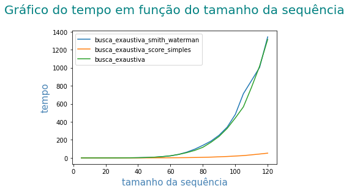

```python
for exe in df_exaustiva.columns.values.tolist():
    plt.plot(valores,multiIndex_df_exaustiva[exe]["times"].values, label=exe)
plt.legend()
plt.xlabel("tamanho da sequência",
           fontsize=15,
          color="steelblue")
plt.ylabel("tempo",
           fontsize=15,
          color="steelblue")
plt.title(label="Gráfico do tempo em função do tamanho da sequência\n",
          fontsize=20,
          color="teal")
```

##### Gráfico da comparação de valores

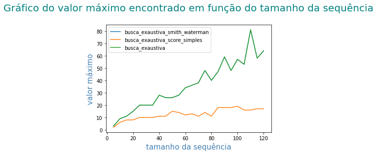

```python
for exe in df_exaustiva.columns.values.tolist():
    plt.plot(valores,multiIndex_df_exaustiva[exe]["results"].values.astype(float), label=exe)
plt.legend()
plt.xlabel("tamanho da sequência",
           fontsize=15,
          color="steelblue")
plt.ylabel("valor máximo",
           fontsize=15,
          color="steelblue")
plt.title(label="Gráfico do valor máximo encontrado em função do tamanho da sequência\n",
          fontsize=20,
          color="teal")
```

O gráfico do tempo em função do tamanho da sequência mostrou que o desempenho da busca exaustiva com o alinhamento calculado pelo método de Smith Waterman teve um desempenho muito similar em termos de velocidade ao método que mesclava Smith Waterman com o cálculo de score simples. Ambos aparentam possuir complexidade O(n²), apresentando uma curva exponencial.

Este resultado condiz com o esperado, pois gerar todas as subsequências possíveis envolve a presença de dois loops aninhados, o que é de fato algo muito custoso.

Além disso, ao calcular os scores de tais subsequências, na maior parte das comparações, o tamanho entre as elas será diferente, de forma que na realidade a maior parte dos cálculos se dará pelo próprio método de Smith Waterman.

Por precisar montar uma matriz e calcular o score em cada posição com dependência dos valores das posições vizinhas, este método é de fato demorado. Além disso, ele inclui a reconstrução do alinhamento das sequências, em que um caminho dentro da matriz deve ser percorrido novamente. O processo como um todo é bem mais complexo do que uma comparação simples, feita a partir de uma mesma posição em duas sequências distintas, o que consequentemente eleva significativamente o tempo de processamento.

Além disso, é possível observar que existe um limiar em torno do tamanho das sequências igual a 50, a partir do qual o tempo de processamento dos programas com o uso do método de Smith Waterman cresce mais.

Ou seja, a partir de tal limiar, a utilização de tais métodos pode apresentar desvantagens em relação ao tempo de processamento, sendo que quanto maior o tamanho da sequência, pior será o desempenho.

Contudo, estes métodos apresentaram vantagens em relação ao desempenho, como mostra o gráfico do valor máximo encontrado em função do tamanho da sequência.

Para tamanhos de sequência menores (cerca de abaixo de 10), os resultados do alinhamento calculado por Smith Waterman e pelo método de alinhamento simples não diferiram significativamente. Porém, conforme o tamanho da sequência aumenta, o gráfico mostra que o cálculo por score simples possui um desempenho nitidamente inferior. Isso se dá pelo fato deste método não considerar os gaps no alinhamento, conforme é calculado no método de Smith Waterman.

## Comparação de todos os algoritmos implementados em CPU

Para que fosse possível obter uma visão geral comparativa entre todas as implementações desenvolvidas, foram plotadas todas as implementações em um único gráfico. Para a busca exaustiva, foram utilizados os dados do modelo da regressão, para que o range de tamanhos de entradas analisado pudesse ser maior.

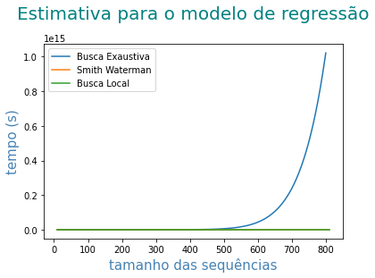

```python
executaveis_omp =["exaustiva-paralela-reduce","exaustiva-paralela"]
valores, df_omp, multiIndex_df_omp = create_df(executaveis_omp, 5, 28, 5)

exe_list = ["busca_exaustiva_smith_waterman", "exaustiva-paralela-reduce"]
df_ex_concat = pd.concat([multiIndex_df_exaustiva["busca_exaustiva_smith_waterman"], multiIndex_df_omp["exaustiva-paralela-reduce"].reindex(multiIndex_df_exaustiva["busca_exaustiva_smith_waterman"].index)], axis=1, keys=exe_list)
dic = df_ex_concat.to_dict()

df_regression_sw = exhaustive_regression(10, 800, 10, dic, df_ex_concat.index.values)
plt.plot(df_regression_sw["size"],df_regression_sw["times_sw"].values, label="Busca Exaustiva")
plt.plot(multiIndex_df_p1_p2.index.values,multiIndex_df_p1_p2["smith_waterman"]["times"].values.astype(float), label="Smith Waterman")
plt.plot(multiIndex_df_p1_p2.index.values,multiIndex_df_p1_p2["busca-local"]["times"].values.astype(float), label="Busca Local")
plt.legend()
plt.xlabel("tamanho das sequências",
           fontsize=15,
          color="steelblue")
plt.ylabel("tempo (s)",
           fontsize=15,
          color="steelblue")
plt.title(label="Estimativa para o modelo de regressão\n",
          fontsize=20,
          color="teal")
```

Para se obter uma visão comparativa mais direta entre as proporções de tempo que cada estratégia implementada leva em relação às outras, cada valor obtido de tempo foi dividido pelo menor obtido. Desta forma, é possível realizar uma análise comparativa com valores relativos.

```python
df_times_merge = pd.merge(multiIndex_df_p1_p2, df_regression_sw, left_index=True, right_index=True)
df_times = df_times_merge.iloc[:, [1, 3,5]]
column_names=["smith_waterman", "busca-local", "busca-exaustiva"]
df_times.columns = column_names
```

```python
df_times/df_times.values.min()
```

|  | smith_waterman | busca-local | busca-exaustiva |
| --- | --- | --- | --- |
| 10 | 1.719428 | 1.605900 | 4.697879e+02 |
| 60 | 1.085330 | 12.654316 | 1.407320e+04 |
| 110 | 1.000000 | 39.142522 | 2.655027e+05 |
| 160 | 1.030436 | 97.248427 | 5.314967e+08 |
| 210 | 1.137340 | 159.704005 | 3.381454e+10 |
| 260 | 1.859034 | 225.871476 | 5.875403e+11 |
| 310 | 1.376509 | 343.720485 | 5.288546e+12 |
| 360 | 1.467173 | 492.431710 | 3.173535e+13 |
| 410 | 1.580274 | 609.181268 | 1.443662e+14 |
| 460 | 1.812333 | 786.301216 | 5.366896e+14 |
| 510 | 2.038587 | 986.398029 | 1.710554e+15 |
| 560 | 2.122259 | 1141.771936 | 4.828859e+15 |
| 610 | 2.461292 | 1450.670900 | 1.235668e+16 |
| 660 | 2.596386 | 1577.230462 | 2.915565e+16 |
| 710 | 2.974337 | 1877.522678 | 6.425913e+16 |
| 760 | 3.109899 | 2125.715837 | 1.336325e+17 |

Os resultados mostraram que o algoritmo com melhor desempenho em termos de velocidade foi o de Smith Waterman.

Para valores de entrada maiores, a busca local chegou a ter um desempenho mais de 2 mil vezes pior em termos de tempo em relação ao mais rápido de Smith Waterman.

Contudo, os piores resultados foram claramente aqueles da busca exaustiva. Com uma entrada de tamanho 760, o resultado obtido foi na ordem de 10^17 vezes pior do que a implementação mais rápida.

É importante também ressaltar que , conforme os valores do tamanho da entrada sobem, a diferença entre os algoritmos implementados cresce muito rapidamente.

## Busca exaustiva com paralelismo

```python
multiIndex_df_omp
```

| tamanho-entrada | exaustiva-paralela-reduce results | exaustiva-paralela-reduce times | exaustiva-paralela results | exaustiva-paralela times |
| --- | --- | --- | --- | --- |
| 5 | 3 | 0.180528 | 3 | 0.007471 |
| 10 | 9 | 0.195958 | 9 | 0.008663 |
| 15 | 11 | 0.218423 | 11 | 0.021905 |
| 20 | 15 | 0.375635 | 15 | 0.051858 |
| 25 | 20 | 0.695848 | 20 | 0.180670 |
| 30 | 20 | 1.541433 | 20 | 0.459847 |
| 35 | 20 | 2.840102 | 20 | 1.019448 |
| 40 | 28 | 5.364007 | 28 | 1.989056 |
| 45 | 26 | 8.706916 | 26 | 3.483304 |
| 50 | 26 | 13.822645 | 26 | 5.789430 |
| 55 | 28 | 17.295643 | 28 | 10.869762 |
| 60 | 34 | 32.366767 | 34 | 18.396621 |
| 65 | 36 | 86.460383 |  | 44.895416 |
| 70 | 38 | 124.699569 |  | 8.162227 |
| 75 | 48 | 94.925606 |  | 4.635183 |
| 80 | 40 | 86.898225 |  | 6.687696 |
| 85 | 47 | 121.476991 |  | 6.406726 |
| 90 | 59 | 170.599678 |  | 5.528130 |
| 95 | 48 | 235.750163 |  | 6.406919 |
| 100 | 57 | 302.494883 |  | 5.181697 |
| 105 | 53 | 343.038634 |  | 5.358833 |
| 110 | 81 | 495.300285 |  | 5.290223 |
| 115 | 58 | 558.964983 |  | 5.437991 |
| 120 | 64 | 773.667861 |  | 5.546290 |
| 125 | 74 | 929.846110 |  | 5.665834 |
| 130 | 67 | 1239.290978 |  | 4.299512 |
| 135 | 72 | 1361.891876 |  | 4.312812 |
| 140 | 82 | 2142.010904 |  | 6.691571 |

#### Gráfico do tempo em função do tamanho da sequência

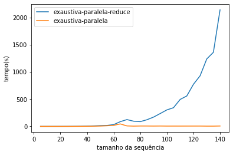

```python
for exe in df_omp.columns.values.tolist():
    plt.plot(valores,multiIndex_df_omp[exe]["times"].values.astype(float), label=exe)
plt.legend()
plt.xlabel("tamanho da sequência")
plt.ylabel("tempo(s)")
```

A linha laranja do gráfico, correspondente à primeira implementação descrita, mostra claramente o momento em que o vetor de todas as subsequências geradas ficou grande demais e acabou por causar um estouro na memória.

Nota-se que a curva azul, correspondente à segunda iteração do programa, em que as combinações de subsequências são geradas e seus resultados calculados em blocos, não teve este problema e conseguiu obter resultados para sequências de entradas bem maiores.

## Comparação Paralelismo

```python
df_ex_concat
```

| tamanho-entrada | busca_exaustiva_smith_waterman results | busca_exaustiva_smith_waterman times | exaustiva-paralela-reduce results | exaustiva-paralela-reduce times |
| --- | --- | --- | --- | --- |
| 5 | 3 | 0.013626 | 3 | 0.180528 |
| 10 | 9 | 0.011163 | 9 | 0.195958 |
| 15 | 11 | 0.024221 | 11 | 0.218423 |
| 20 | 15 | 0.093755 | 15 | 0.375635 |
| 25 | 20 | 0.183553 | 20 | 0.695848 |
| 30 | 20 | 0.444567 | 20 | 1.541433 |
| 35 | 20 | 1.047893 | 20 | 2.840102 |
| 40 | 28 | 2.278776 | 28 | 5.364007 |
| 45 | 26 | 4.446800 | 26 | 8.706916 |
| 50 | 26 | 7.186111 | 26 | 13.822645 |
| 55 | 28 | 13.832409 | 28 | 17.295643 |
| 60 | 34 | 22.420194 | 34 | 32.366767 |
| 65 | 36 | 39.006012 | 36 | 86.460383 |
| 70 | 38 | 63.477488 | 38 | 124.699569 |
| 75 | 48 | 96.838354 | 48 | 94.925606 |
| 80 | 40 | 139.381786 | 40 | 86.898225 |
| 85 | 47 | 186.118298 | 47 | 121.476991 |
| 90 | 59 | 251.434545 | 59 | 170.599678 |
| 95 | 48 | 341.369135 | 48 | 235.750163 |
| 100 | 57 | 481.273954 | 57 | 302.494883 |
| 105 | 53 | 712.133316 | 53 | 343.038634 |
| 110 | 81 | 857.171326 | 81 | 495.300285 |
| 115 | 58 | 1003.539804 | 58 | 558.964983 |
| 120 | 64 | 1342.300932 | 64 | 773.667861 |

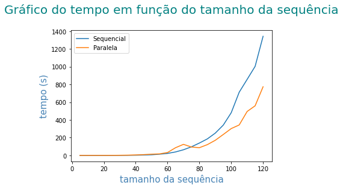

```python
labels_list = ["Sequencial", "Paralela"]
i=0
for exe in exe_list:
    plt.plot(df_ex_concat.index.values,df_ex_concat[exe]["times"].values, label=labels_list[i])
    i+=1
plt.legend()
plt.xlabel("tamanho da sequência",
           fontsize=15,
          color="steelblue")
plt.ylabel("tempo (s)",
           fontsize=15,
          color="steelblue")
plt.title(label="Gráfico do tempo em função do tamanho da sequência\n",
          fontsize=20,
          color="teal")
```

Para valores mais baixos, até cerca de 60 para ambas as sequências, nota-se que não existe muita diferença de tempo entre as implementações paralela e sequencial. No entanto, para valores maiores, nota-se que a curva da implementação sequencial (em azul) cresce muito mais rapidamente do que a paralela.

## Regressão

#### Criando o modelo

```python
 df_regression_sw = exhaustive_regression(10, 120, 10, dic, df_ex_concat.index.values)
```

##### Validação visual

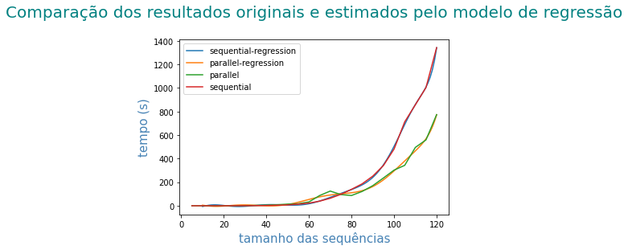

```python
plt.plot(df_regression_sw["size"],df_regression_sw["times_sw"].values, label="sequential-regression")
plt.plot(df_regression_sw["size"],df_regression_sw["times_exe"].values, label="parallel-regression")
plt.plot(df_ex_concat.index.values,df_ex_concat["exaustiva-paralela-reduce"]["times"].values, label="parallel")
plt.plot(df_ex_concat.index.values,df_ex_concat["busca_exaustiva_smith_waterman"]["times"].values, label="sequential")

plt.legend()
plt.xlabel("tamanho das sequências",
           fontsize=15,
          color="steelblue")
plt.ylabel("tempo (s)",
           fontsize=15,
          color="steelblue")
plt.title(label="Comparação dos resultados originais e estimados pelo modelo de regressão\n",
          fontsize=20,
          color="teal")
```

#### Estimativas para sequências maiores

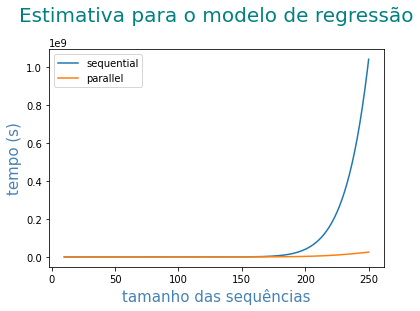

```python
df_regression_sw = exhaustive_regression(10, 250, 10, dic, df_ex_concat.index.values)
plt.plot(df_regression_sw["size"],df_regression_sw["times_sw"].values, label="sequential")
plt.plot(df_regression_sw["size"],df_regression_sw["times_exe"].values, label="parallel")
plt.legend()
plt.xlabel("tamanho das sequências",
           fontsize=15,
          color="steelblue")
plt.ylabel("tempo (s)",
           fontsize=15,
          color="steelblue")
plt.title(label="Estimativa para o modelo de regressão\n",
          fontsize=20,
          color="teal")
```

A diferença entre os tempos de processamento fica ainda mais evidente após realizada a regressão. A curva referente ao processamento sequencial (em azul) indica um crescimento extremamente mais rápido, sendo que uma entrada com duas sequências de tamanho em torno de 250 demoraria cerca de um bilhão de segundos, o que chega a ser inviável na prática.

Já a curva referente à implementação paralela (laranja) apresentou uma taxa de crescimento significativamente inferior.

## GPU

```python
executaveis =["exhaustive-GPU", "exhaustive-GPU3"]
valores, df_gpu, multiIndex_df_gpu = create_df(executaveis, 5, 7, 5)
```

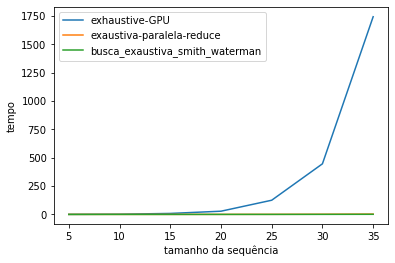

```python
exe_list = ["exhaustive-GPU", "exaustiva-paralela-reduce", "busca_exaustiva_smith_waterman"]

df_ex_concat_gpu = pd.concat([multiIndex_df_gpu["exhaustive-GPU"],
                              multiIndex_df_omp["exaustiva-paralela-reduce"].reindex(multiIndex_df_gpu["exhaustive-GPU"].index),
                             multiIndex_df_exaustiva["busca_exaustiva_smith_waterman"].reindex(multiIndex_df_gpu["exhaustive-GPU"].index)],
                             axis=1, keys=exe_list)

for exe in exe_list:
    plt.plot(valores,df_ex_concat_gpu[exe]["times"].values.astype(float), label=exe)
plt.legend()
plt.xlabel("tamanho da sequência")
plt.ylabel("tempo")
```

O gráfico mostra que o programa implementado em GPU com o paralelismo com OpenMP não teve um desempenho como esperado, ficando mais lento. Visando a melhor compreender os motivos disso e a possivelmente melhorar os resultados, foi implementada outra estratégia, desta vez sem o OpenMP

```python
multiIndex_df_gpu
```

| tamanho-entrada | exhaustive-GPU results | exhaustive-GPU times | exhaustive-GPU3 results | exhaustive-GPU3 times |
| --- | --- | --- | --- | --- |
| 5 | 3 | 0.389701 | 3\n | 0.316089 |
| 10 | 7 | 1.929661 | 7\n | 0.855413 |
| 15 | 11 | 8.629662 | 12\n | 2.570013 |
| 20 | 18 | 28.323067 | 18\n | 7.167047 |
| 25 | 14 | 125.101002 | 14\n | 26.282668 |
| 30 | 20 | 446.094157 | 20\n | 49.393199 |
| 35 | 29 | 1742.592518 | 29\n | 74.705712 |

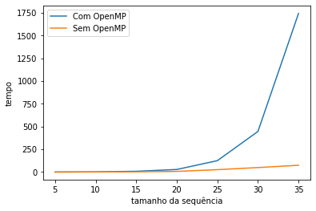

```python
labels_list = ["Com OpenMP", "Sem OpenMP"]
i=0
for exe in df_gpu.columns.values.tolist():
    plt.plot(valores,multiIndex_df_gpu[exe]["times"].values.astype(float), label=labels_list[i])
    i+=1
plt.legend()
plt.xlabel("tamanho da sequência")
plt.ylabel("tempo")
```

Os resultados mostraram que esta segunda estratégia implementada teve um desempenho superior à primeira.

```python
exe_list = ["exhaustive-GPU3", "exaustiva-paralela-reduce", "busca_exaustiva_smith_waterman"]

df_ex_concat_gpu = pd.concat([multiIndex_df_gpu["exhaustive-GPU3"],
                              multiIndex_df_omp["exaustiva-paralela-reduce"].reindex(multiIndex_df_gpu["exhaustive-GPU3"].index),
                             multiIndex_df_exaustiva["busca_exaustiva_smith_waterman"].reindex(multiIndex_df_gpu["exhaustive-GPU3"].index)],
                             axis=1, keys=exe_list)
```

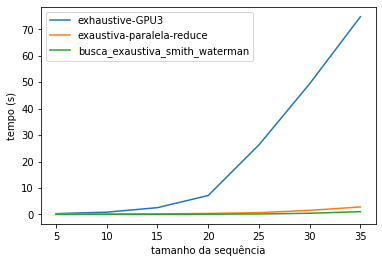

```python
for exe in exe_list:
    plt.plot(valores,df_ex_concat_gpu[exe]["times"].values.astype(float), label=exe)
plt.legend()
plt.xlabel("tamanho da sequência")
plt.ylabel("tempo (s)")
```

Mesmo com essa nova estratégia implementada, o desempenho não foi bom, sendo pior do que as outras implementadas anteriormente

Quando a implementação do paralelismo foi retirada, o programa rodou mais rápido. Uma possível explicação é que a implementação com OpenMP gerava as subsequencias em blocos em um vetor e depois disso enviava cada um desses blocos para a GPU. Além do processamento mais lento causado pela geração do vetor com todos os pares subsequencias e a geração de batches menores para o cálculo do score, a transferência da GPU ocorria por partes e por blocos menores. Considerando que este processo de transferência é muito lento, é de se esperar que quando ele ocorre múltiplas vezes com menos dados de cada vez o programa demore mais de fato.

Além disso, o OpenMP pode causar um problema de escalonamento dos threads.

Normalmente o OpenMP usa o escalonamento estático, em que ele distribui as iterações em blocos entre as threads. Neste sentido, podem existir threads que tenham que calcular o score para subsequencias muito maiores do que outras threads.

Desta maneira, as threads que processarem sequências de tamanhos maiores levarão muito mais tempo do que aquelas que processam sequências de tamanho inferior.

Isso se torna mais evidente conforme o tamanho das sequências de entrada cresce, fazendo com que o tamanho das subsequencias geradas sejam cada vez mais divergentes.

Na prática, as threads que rodam mais rápido podem ficar ociosas.

Desta forma, o paralelismo acaba sendo prejudicado.

# Profiling

### Metodologia

Para identificar os principais pontos que poderiam ser aprimorados nos códigos, foi usada a ferramenta Valgrind. Para isso, foram utilizados os seguintes comandos:

```
            g++ -Wall -O3 -g programa.cpp -o programa
            valgrind --tool=callgrind ./programa
            callgrind_annotate callgrind.out.NUM programa.cpp
```

### Resultados

Alguns pontos de possíveis melhorias foram mostrados em diferentes códigos:

##### Smith Waterman

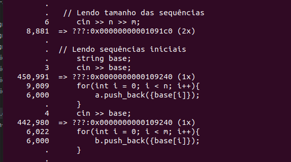

A leitura das bases nitrogenadas e cópia de cada caractere para um vetor de strings foi indicada como uma operação custosa. Uma forma de evitar isso seria ler tais valores diretamente como uma string, sem copiá-los para um vetor (o que foi implementado no último projeto)

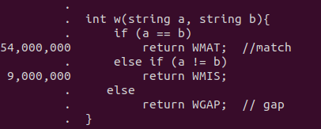

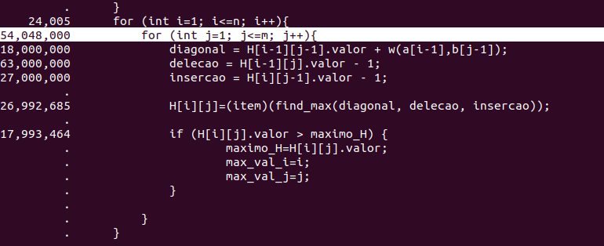

Outra indicação foram as a funções utilizadas na composição da matriz de Smith Waterman. Esta parte dos códigos é realmente muito custosa, já que cria uma grande estrutura de dados (matriz H).

##### Busca Local

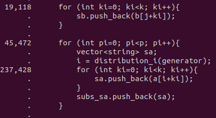

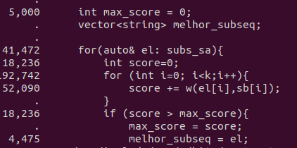

No caso da busca local, um trecho que foi um motivo importante para lentidão foi a criação da matriz com todas as subsequências de A.

Além disso, o cálculo do score também foi muito custoso por também possuir um loop aninhado.

Uma possível ideia seria combinar os dois trechos, retirando assim a necessidade de repetir o loop com outro interno, de forma a otimizar o programa.

##### Busca Exaustiva

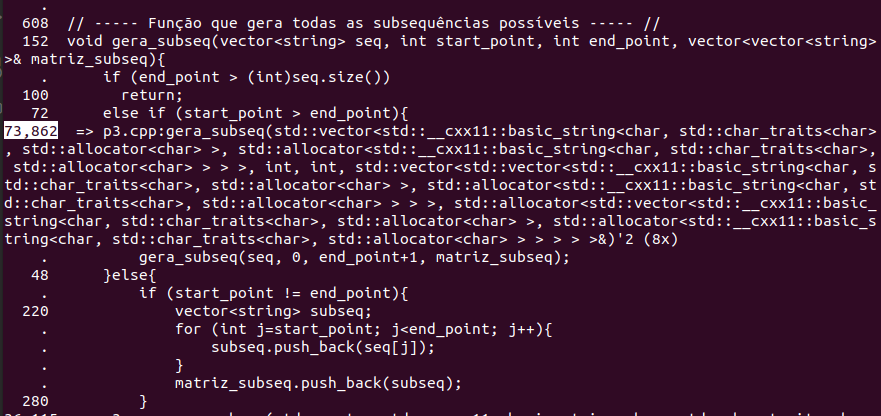

Conforme esperado, um ponto importante de dalays no código foi a geração de todas as subsequências.

Este ponto poderia ser melhorado por meio da implementação da estratégia de Branch and Bound (implementado no último projeto).

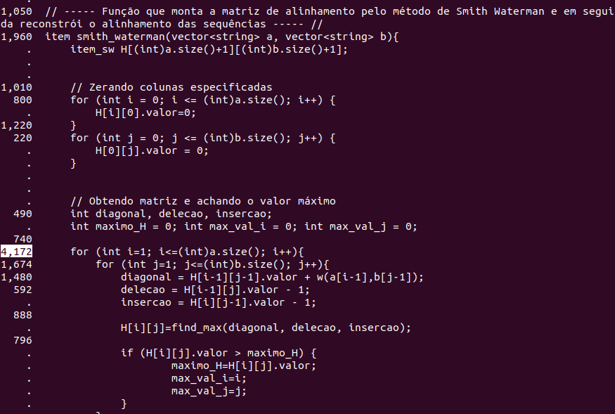

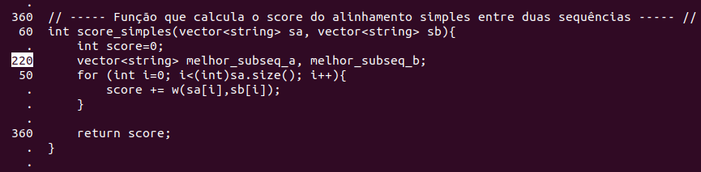

O cálculo de scores pelo método do Smith Waterman também teve alto custo computacional, conforme mostrado na análise da primeira parte do projeto.

Além disso, é interessante notar que na busca exaustiva com o cálculo de score misto (com o visto acima), o score simples é rodado muito menos vezes, já que na maior parte das vezes os tamanhos das sequências são diferentes.

### Paralela - OpenMP

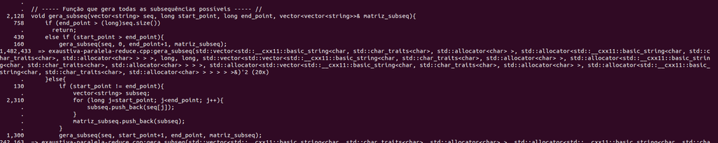

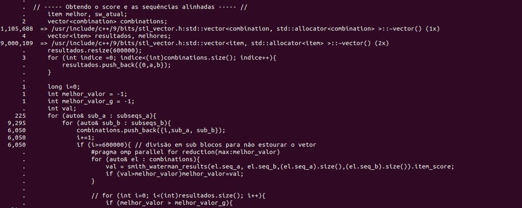

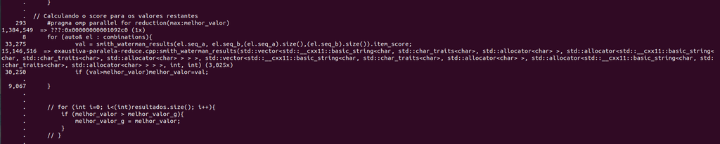

Conforme esperado, as operações mais custosas computacionalmente foram relacionadas ao cálculo do score.

A geração de uma grande matriz para calcular os scores ainda foi um ponto de lentidão importante.

Outro ponto crucial, foi a geração de todas as subsequencias possíveis, que realmente alcançam uma quantidade muito alta a depender do tamanho da entrada. Desta forma, o loop de adicioná-las ao vetor de pares de subsequencias pode ficar lento por ter que realizar a mesma operação inúmeras vezes.

### GPU

###### com OpenMP

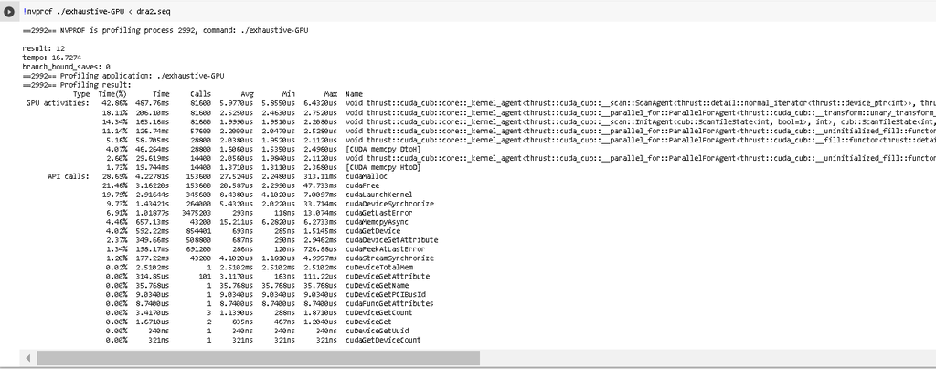

###### Sem OpenMP

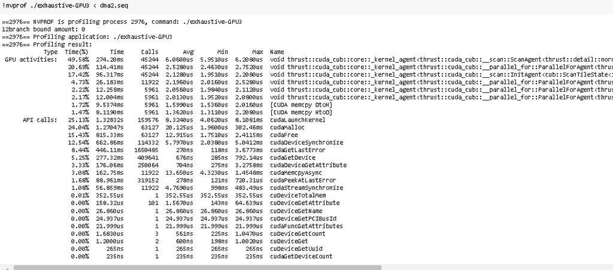

# Principais pontos de lentidão identificados

##### Smith Waterman

O trecho mais custoso computacionalmente consiste na construção da matriz de structs, que é uma grande estrutura de dados que aumenta de forma significativa conforme o tamanho das sequências aumentam.

##### Busca Local

O principal ponto que aparenta ter causado lentidão nesta estratégia foi o fato de o programa ser rodado diversas vezes (valor definido como 1000), com o intuito de gerar diversos valores diferentes de p e k e assim testar mais sequências, aumentando as chances de encontrar um score melhor.

Diminuindo tal valor, é esperado que o tempo de execução caia também.

Desta forma, este valor deve ser ajustado conforme as necessidades de uso, se deseja-se favorecer o desempenho ou o tempo de execução.

Formas de melhorar o desempenho poderiam incluir uma checagem se os valores de k já foram sorteados ou até mesmo se o maior score possível para o tamanho daquela sequência sorteado seria menor do que aquele já encontrado.

Outra ideia seria realizar uma checagem se o valor máximo encontrado aparenta se estabilizar e no caso positivo, encerrar a execução do programa.

##### Busca Exaustiva

Um ponto de lentidão muito importante nesta estratégia consiste na geração de todas as possíveis sequências e o cálculo de seus respectivos scores. Conforme o tamanho das sequências de entrada aumenta, a quantidade de subsequências geradas fica realmente muito alta. Ademais, nas implementações com Smith Waterman, uma grande estrutura de dados na forma de matriz é criada para cada subsequência. Desta forma, já era esperado que este processamento demorasse.

##### OpenMP

A implementação da parelelização do cálculo dos scores por threads melhorou muito o desempenho. No entanto, ainda existem processos lentos, que aumentam o tempo de execução do programa.

A geração de todas as subsequências a serem acrescentadas no vetor de combinações foi indicada como um ponto de lentidão. O principal trecho mais computacionalmente custoso, porém, foi o do cálculo de scores por Smith Waterman.

##### GPU

O grande problema da implementação em GPU foi a lentidão causada pelo processamento paralelo não efetivo. Uma possibilidade para melhorar o desempenho do programa seria realizar o processamento inteiramente dentro da GPU, de forma a paralelizar os processos mais efetivamente.

# Conclusões

As análises mostraram que aquelas implementações com melhores resultados de score foram as mesmas com os piores desempenhos em relação ao tempo. Desta forma, é importante considerar quais os objetivos de cada aplicação específica, de forma a possibilitar a escolha mais adequada para a metodologia de implementação, visando a favorecer determinado aspecto em relação a outro.

A solução implementada mais computacionalmente custosa foi claramente a busca exaustiva. Contudo, a introdução do paralelismo com OpenMP melhorou a performance de forma significativa, possibilitando que sequências de entrada de tamanho muito maior rodassem em menos tempo.